# Análise de influência de propriedades químicas na qualidade de Vinhos Tintos

by Rafael Tomaz

#### Introdução

O objetivo deste projeto é fazer uma explocação preliminar nos dados de vinhos tintos do dataset, que compõem de variaveis quimicas do vinho e a qualidade, e verificar quais dessas propriedades tem mais relação com a qualidade do vinho tinto.

> Citação do dataset conforme solicitação do autor:

P. Cortez, A. Cerdeira, F. Almeida, T. Matos and J. Reis. Modeling wine preferences by data mining from physicochemical properties. In Decision Support Systems, Elsevier, 47(4):547-553. ISSN: 0167-9236.

Available at: [@Elsevier] http://dx.doi.org/10.1016/j.dss.2009.05.016 [Pre-press (pdf)] http://www3.dsi.uminho.pt/pcortez/winequality09.pdf [bib] http://www3.dsi.uminho.pt/pcortez/dss09.bib

#### Carregamento dos dados

Os conjunto de dados escolhido foi a de qualidade de vinhos tintos **wineQualityReds.csv** que já se encontra em uma estrutura e é utilizado em diversos trabalhos e disputas de analises de dados e machine learning, segue abaixo mais informações sobre os dados:

Origem dos dados: [Red Wine Quality](https://docs.google.com/document/d/1jX3vzkFuFOBGUrlcQ_Lc3jEZVlC_2yyk3tFIbwAI5GQ/edit)

Conjunto de Dados:

7. Attribute information:

For more information, read [Cortez et al., 2009].

##### Input variables (based on physicochemical tests):

1 - fixed acidity (tartaric acid - g / dm^3)

2 - volatile acidity (acetic acid - g / dm^3)

3 - citric acid (g / dm^3)

4 - residual sugar (g / dm^3)

5 - chlorides (sodium chloride - g / dm^3

6 - free sulfur dioxide (mg / dm^3)

7 - total sulfur dioxide (mg / dm^3)

8 - density (g / cm^3)

9 - pH

10 - sulphates (potassium sulphate - g / dm3)

11 - alcohol (% by volume)

##### Output variable (based on sensory data):

12 - quality (score between 0 and 10)

9. Description of attributes:

1 - fixed acidity: most acids involved with wine or fixed or nonvolatile (do not evaporate readily)

2 - volatile acidity: the amount of acetic acid in wine, which at too high of levels can lead to an unpleasant, vinegar taste

3 - citric acid: found in small quantities, citric acid can add ‘freshness’ and flavor to wines

4 - residual sugar: the amount of sugar remaining after fermentation stops, it’s rare to find wines with less than 1 gram/liter and wines with greater than 45 grams/liter are considered sweet

5 - chlorides: the amount of salt in the wine

6 - free sulfur dioxide: the free form of SO2 exists in equilibrium between molecular SO2 (as a dissolved gas) and bisulfite ion; it prevents microbial growth and the oxidation of wine

7 - total sulfur dioxide: amount of free and bound forms of S02; in low concentrations, SO2 is mostly undetectable in wine, but at free SO2 concentrations over 50 ppm, SO2 becomes evident in the nose and taste of wine

8 - density: the density of water is close to that of water depending on the percent alcohol and sugar content

9 - pH: describes how acidic or basic a wine is on a scale from 0 (very acidic) to 14 (very basic); most wines are between 3-4 on the pH scale

10 - sulphates: a wine additive which can contribute to sulfur dioxide gas (S02) levels, wich acts as an antimicrobial and antioxidant

11 - alcohol: the percent alcohol content of the wine

Output variable (based on sensory data): 12 - quality (score between 0 and 10)

# Seção de Gráficos Univariados

```
## [1] 1599   12
```

```
## 'data.frame':    1599 obs. of  12 variables:
##  $ fixed.acidity       : num  7.4 7.8 7.8 11.2 7.4 7.4 7.9 7.3 7.8 7.5 ...
##  $ volatile.acidity    : num  0.7 0.88 0.76 0.28 0.7 0.66 0.6 0.65 0.58 0.5 ...
##  $ citric.acid         : num  0 0 0.04 0.56 0 0 0.06 0 0.02 0.36 ...
##  $ residual.sugar      : num  1.9 2.6 2.3 1.9 1.9 1.8 1.6 1.2 2 6.1 ...
##  $ chlorides           : num  0.076 0.098 0.092 0.075 0.076 0.075 0.069 0.065 0.073 0.071 ...
##  $ free.sulfur.dioxide : num  11 25 15 17 11 13 15 15 9 17 ...
##  $ total.sulfur.dioxide: num  34 67 54 60 34 40 59 21 18 102 ...
##  $ density             : num  0.998 0.997 0.997 0.998 0.998 ...
##  $ pH                  : num  3.51 3.2 3.26 3.16 3.51 3.51 3.3 3.39 3.36 3.35 ...
##  $ sulphates           : num  0.56 0.68 0.65 0.58 0.56 0.56 0.46 0.47 0.57 0.8 ...
##  $ alcohol             : num  9.4 9.8 9.8 9.8 9.4 9.4 9.4 10 9.5 10.5 ...
##  $ quality             : int  5 5 5 6 5 5 5 7 7 5 ...
```

```
##  fixed.acidity   volatile.acidity  citric.acid    residual.sugar
##  Min.   : 4.60   Min.   :0.1200   Min.   :0.000   Min.   : 0.900
##  1st Qu.: 7.10   1st Qu.:0.3900   1st Qu.:0.090   1st Qu.: 1.900
##  Median : 7.90   Median :0.5200   Median :0.260   Median : 2.200
##  Mean   : 8.32   Mean   :0.5278   Mean   :0.271   Mean   : 2.539
##  3rd Qu.: 9.20   3rd Qu.:0.6400   3rd Qu.:0.420   3rd Qu.: 2.600
##  Max.   :15.90   Max.   :1.5800   Max.   :1.000   Max.   :15.500
##    chlorides       free.sulfur.dioxide total.sulfur.dioxide
##  Min.   :0.01200   Min.   : 1.00       Min.   :  6.00
##  1st Qu.:0.07000   1st Qu.: 7.00       1st Qu.: 22.00
##  Median :0.07900   Median :14.00       Median : 38.00
##  Mean   :0.08747   Mean   :15.87       Mean   : 46.47
##  3rd Qu.:0.09000   3rd Qu.:21.00       3rd Qu.: 62.00
##  Max.   :0.61100   Max.   :72.00       Max.   :289.00
##     density             pH          sulphates         alcohol
##  Min.   :0.9901   Min.   :2.740   Min.   :0.3300   Min.   : 8.40
##  1st Qu.:0.9956   1st Qu.:3.210   1st Qu.:0.5500   1st Qu.: 9.50
##  Median :0.9968   Median :3.310   Median :0.6200   Median :10.20
##  Mean   :0.9967   Mean   :3.311   Mean   :0.6581   Mean   :10.42
##  3rd Qu.:0.9978   3rd Qu.:3.400   3rd Qu.:0.7300   3rd Qu.:11.10
##  Max.   :1.0037   Max.   :4.010   Max.   :2.0000   Max.   :14.90
##     quality
##  Min.   :3.000
##  1st Qu.:5.000
##  Median :6.000
##  Mean   :5.636
##  3rd Qu.:6.000
##  Max.   :8.000
```

```
## [1] "Quantidade e observações que não possuem acido citrico"
```

```
##   n()
## 1 132
```

```
## [1] "Quantidade e observações que o açucar residual é menor que 2.7"
```

```
##    n()
## 1 1245
```

##### Observações do Resumo

- O conjunto de dados possui 1599 observações com 13 colunas/atributos, sendo 1 atributo X sendo o índice ou Id da amostra, 11 atributos físico-químicas e uma variável de qualidade de saída medindo o escore de qualidade dado por especialistas de vinho.
- Existe uma grande variedade de dioxido de enxofre (livre e total) nas amostras.
- O teor alcólico varia de 8.40 a 14.90, com uma mediana de 10.20, para as amostras no conjunto de dados.
- A qualidade das amostras varia de 3 a 8, sendo 6 a mediana.
- A faixa de acidez fixa é bastante alta, com um mínimo de 4.60 e um máximo de 15.90
- O valor do pH varia de 2.740 a 4.010, com uma mediana de 3.310.
- Menos de 9% das observações não possuem ácido citrico
- Cerca de 75% dos vinho possuem o açucar residual inferior a 2.7

#### Geração de gráficos

##### Análise inicial de Qualidade

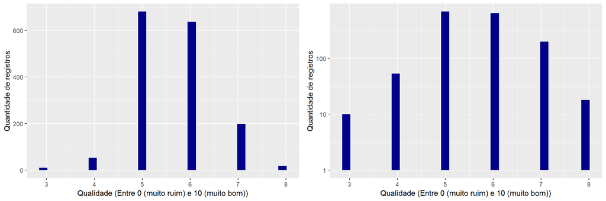

```
## [1] "Summary de Qualidade"
```

```
##    Min. 1st Qu.  Median    Mean 3rd Qu.    Max.
##   3.000   5.000   6.000   5.636   6.000   8.000
```

```
## [1] "Summary de Qualidade: Agrupando qualidade por quantidade"
```

```
## # A tibble: 6 x 2
##   quality `n()`
##     <int> <int>
## 1       3    10
## 2       4    53
## 3       5   681
## 4       6   638
## 5       7   199
## 6       8    18
```

```
## [1] "Summary da nova variável quality.classification"
```

```
## # A tibble: 2 x 2
##   quality.classification `n()`
##                    <dbl> <int>
## 1                      0   744
## 2                      1   855
```

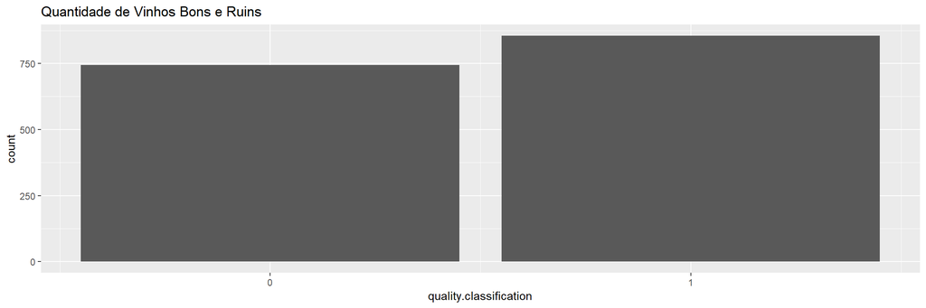

> Conforme verificado nos dados referênte a qualidade do vinho a maioria dos vinhos são de qualidade normal pois a maior parte das observações estão entre 5 e 7, e a mediana é 6, dessa forma posso rotular os vinhos de forma a criar uma nova variável para auxiliar na próximas análises, devido a concentração dos dados estarem entre 5 e 6 será criado uma nova variavel **quality.classification**, onde *‘Ruim’* será para vinhos de baixa qualidade onde possuem qualidade abaixo de 6 e *‘Bom’* de boa qualidade com qualidade superior ou igual à 6.

> É possível ver com a nova classificação que possui mais vinhos de boa qualidade do que de baixa qualidade

##### Análise inicial de Acidez

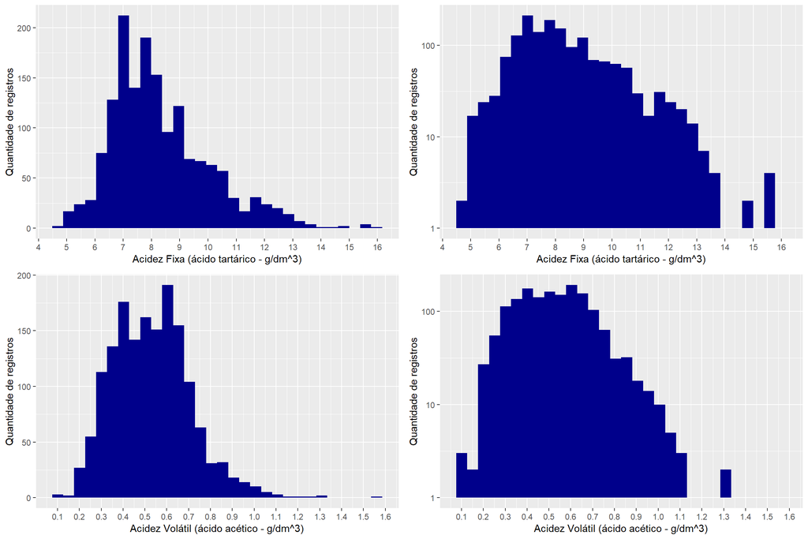

```
## [1] "Summary de Acidez fixa"
```

```
##    Min. 1st Qu.  Median    Mean 3rd Qu.    Max.
##    4.60    7.10    7.90    8.32    9.20   15.90
```

```
## [1] "Summary de Acidez Volátil"
```

```
##    Min. 1st Qu.  Median    Mean 3rd Qu.    Max.
##  0.1200  0.3900  0.5200  0.5278  0.6400  1.5800
```

> Conforme observação do autor do dataset na descrição de atributo quanto maior o a acidez volátil mais desagradável é o vinho, sendo assim o dado de acidez volátil é um dado que pode impactar a qualidade do vinho.

> Com base no [Clube do Vinho](https://www.clubedosvinhos.com.br/acidez-no-vinho-nao-tema/) |Vinhos tintos e brancos tem resultados diferentes frente a acidez. Tintos mais ácidos são mais elegantes, enquanto brancos são mais refrescantes.

> Com base na [Revista Adega](https://revistaadega.uol.com.br/artigo/o-alcool-e-a-acidez_6055.html) |O álcool e acidez são elementos chave do vinho de qualidade. O seu papel é tão fundamental que própria decisão de iniciar vindima é condicionada pelo equilíbrio entre açúcares (que se tornarão álcool após fermentação) e acidez existentes nas uvas.

> Ambas as distribuições acidez fixa e acidez volátil possuem caudas positivas longas, e suas médias são mais alta do que suas medianas, e tornam a mediana uma melhor medida do valor central. Além disso, a distribuição de acidez volátil tem pequena distribuição bimodal.

##### Análise inicial dados que podem ajustar o sabor

###### Açucar Residual, Cloreto de sódio e Ácido Cítrico

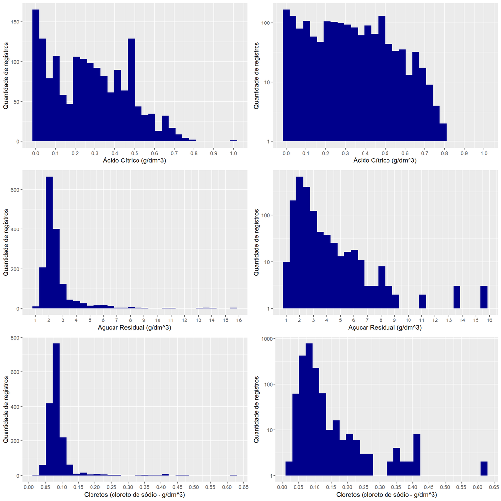

```
## [1] "Summary de Acido Cítrico"
```

```
##    Min. 1st Qu.  Median    Mean 3rd Qu.    Max.
##   0.000   0.090   0.260   0.271   0.420   1.000
```

```
## [1] "Summary de Açucar Residual"
```

```
##    Min. 1st Qu.  Median    Mean 3rd Qu.    Max.
##   0.900   1.900   2.200   2.539   2.600  15.500
```

```
## [1] "Summary de Cloretos"
```

```
##    Min. 1st Qu.  Median    Mean 3rd Qu.    Max.
## 0.01200 0.07000 0.07900 0.08747 0.09000 0.61100
```

> Os parametros de ácido cítrico, açucar residual e cloreto, indicam a saborização do vinho, se será mais salgado, doce ou com refrescante por sabor cítrico.

> Observando os gráficos e a sumariazação dos dados, de “saborização”, as observações estão no centro dos dados entre os o primeiro e terceiro quartil.

> O açúcar residual possui a maior concentração dos dados menor que 2.6, tendo um pico aproximadamente na mediana 2.2

> Os cloretos possuem o mesmo comportamento que que o açucar residual, onde 75% dos dados estao entre 0.012 e 0.09

##### Análise inicial dados que podem ajustar a oxidação e o controle microbial

###### Dióxido de enxofre livre e total e Sulfato de potácio

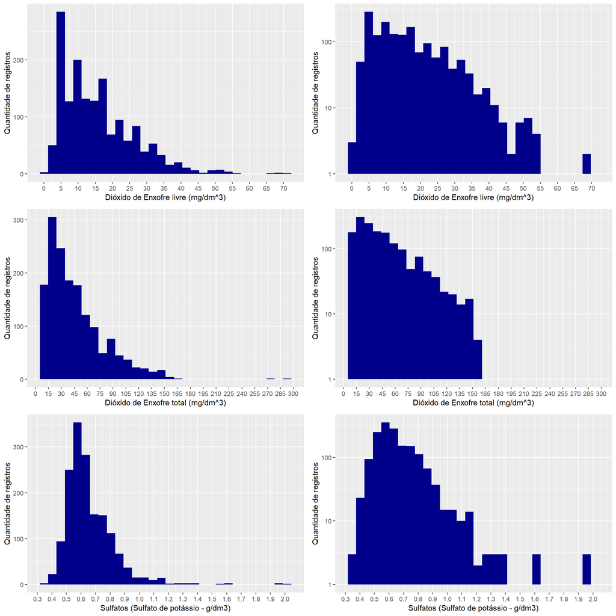

```
## [1] "Summary de Dióxido de Enxofre Livre"
```

```
##    Min. 1st Qu.  Median    Mean 3rd Qu.    Max.
##    1.00    7.00   14.00   15.87   21.00   72.00
```

```
## [1] "Summary de Dióxido de Enxofre Total"
```

```
##    Min. 1st Qu.  Median    Mean 3rd Qu.    Max.
##    6.00   22.00   38.00   46.47   62.00  289.00
```

```
## [1] "Summary de Sulfatos"
```

```
##    Min. 1st Qu.  Median    Mean 3rd Qu.    Max.
##  0.3300  0.5500  0.6200  0.6581  0.7300  2.0000
```

> Conforme descriçoes do autor para dióxido de enxofre e sulfato de potácio, atuam como antimicrobial e antioxidantes, o dióxido de enxofre total, pode interferir no sabor e no aroma.

> A maioria dos valores de sulfatos estão entre 0.3 e 0.7

##### Análise inicial de Densidade e Álcool

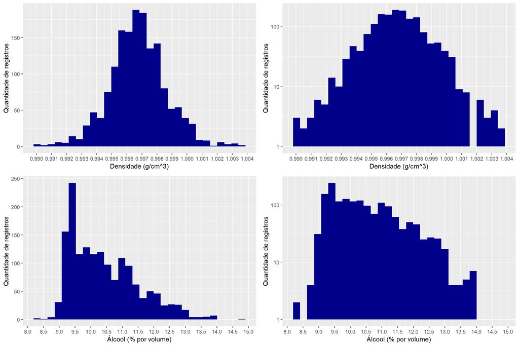

```
## [1] "Summary de Densidade"
```

```
##    Min. 1st Qu.  Median    Mean 3rd Qu.    Max.
##  0.9901  0.9956  0.9968  0.9967  0.9978  1.0037
```

```
## [1] "Summary de Alcool"
```

```
##    Min. 1st Qu.  Median    Mean 3rd Qu.    Max.
##    8.40    9.50   10.20   10.42   11.10   14.90
```

> Conforme o autor, a densidade de água depende do percentual de álcool e a quantidade de açúcar residual no vinho

> A densidade segue uma distribuição normal com média em 0.9967 e mediana de 0.9968

> A distribuição de alcool estão entre mínimo de 8.40 e 14.90, onde 50% das observações estão entre 9.50 e 11.10, a mediana é de 10.20 e a média é de 10.42

##### Análise inicial de pH

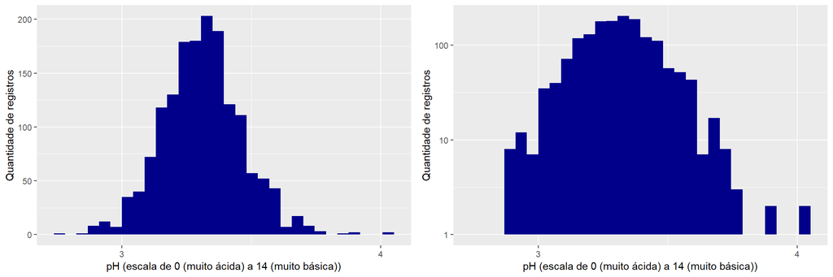

```
## [1] "Summary de pH"
```

```
##    Min. 1st Qu.  Median    Mean 3rd Qu.    Max.
##   2.740   3.210   3.310   3.311   3.400   4.010
```

> Conforme visto no site [Revista Adega do UOL](https://revistaadega.uol.com.br/artigo/a-importancia-do-ph-no-vinho_1552.html): … Nos vinhos tintos, níveis de pH muito baixos estão acompanhados por uma cor roxa brilhante. Assim que o pH vai aumentando, sombras azuladas aparecerão. Em níveis altos de pH, reflexos marrons ficam evidentes …

> Sendo assim, o pH do vinho pode interferir na cor do vinho

> O pH possui uma distribuição normal onde a média e a mediana estão proximas, e a faixa do pH esta aproximadamente entre 2.7 e 4

# Análise Univariada

### Qual é a estrutura do conjunto de dados?

> O Dataset consiste em 1599 observações e 13 atributos, sendo 1 id, 12 atributos e 1 de saída onde: 1 atributo de identificação de amostra “X” sendo o índice, que foi removida pois não fará parte da análise 11 atributos de entrada ( propriedades químicas) (fixed.acidity, volatile.acidity, citric.acid, residual.sugar, chlorides, free.sulfur.dioxide, total.sulfur.dioxide, density, pH, sulphates, alcohol) 1 atributo de saída **qualidade** ( qualidade dos vinhos tintos ), a análise princial será entender quais propriedades qímicas influenciam na qualidade dos vinhos tintos.

Obs: Todos os atributos são numéricos até mesmo a qualidade que é baseado em uma pontuação de 0 a 10, esse recurso é mais facil de ser fatorado para interpretações durante a análise, será criado uma nova variável

### Quais são os principais atributos de interesse deste conjunto de dados?

> A principal característica do conjunto de dados é a qualidade, a idéia principal é tentar avaliar a o comportamento dos demais atributos interferem na qualidade do vinho com alguns outros recursos, utilizando análise bivariada e multivariada.

### Quais outros atributos você acha que podem lhe auxiliar na investigação destes atributos de interesse?

> Eu aprendi, olhando alguns artigos na internet especializados em vinho como está em itens acima da análise, e até mesmo no [link](https://revistaadega.uol.com.br/artigo/o-alcool-e-a-acidez_6055.html) uma boa qualidade do vinho pode ser dada pelo alcool (alcool), gosto ácido (ácidos) e o dioxido de enxofre total pode influenciar no aroma do vinho, portanto pode modificar a qualidade do vinho, portanto podem ser atributos que podem ser relevantes a serem analisados como acidez fixa, acidez volátil, ácido cítrico, dióxido de enxofre álcool e qualidade.

### Você criou novas variáveis a partir dos atributos existentes no conjunto de dados?

> Sim, criei 3 novas variáveis sendo:

> quality.classification para auxiliar em uma classificação mais simples da qualidade de vinhos do especialista se a qualidade for manor que 6 classifiquei como Ruim = 0 e caso seja maior ou igual a 6 classifiquei como Bom = 1

> total.acidity para auxiliar em um calculo de total de acidez do vinho com o total de ácidos do vinho somando a acidez fixa, a acidez volatil e o ácido citrico

> quality.factor para facilitar em uso em gráficos a qualidade como factor

### Dos atributos investigados, distribuições incomuns foram encontradas? Você aplicou operações nos dados para limpá-los, ajustá-los ou mudar a forma dos dados? Se sim, por quê?

> O açucar residual e os cloretos possuem distribuições incomuns e com maior propenções a terem outliers, mesmo com análise em log10 aplicado possui áreas sem valor com valores distantes e com cauda longa e bimodal.

# Seção de Gráficos Bivariados

```
##                      fixed.acidity volatile.acidity citric.acid
## fixed.acidity                1.000          -0.2561       0.672
## volatile.acidity            -0.256           1.0000      -0.552
## citric.acid                  0.672          -0.5525       1.000
## residual.sugar               0.115           0.0019       0.144
## chlorides                    0.094           0.0613       0.204
## free.sulfur.dioxide         -0.154          -0.0105      -0.061
## total.sulfur.dioxide        -0.113           0.0765       0.036
## density                      0.668           0.0220       0.365
## pH                          -0.683           0.2349      -0.542
## sulphates                    0.183          -0.2610       0.313
## alcohol                     -0.062          -0.2023       0.110
## quality                      0.124          -0.3906       0.226
##                      residual.sugar chlorides free.sulfur.dioxide
## fixed.acidity                0.1148    0.0937             -0.1538
## volatile.acidity             0.0019    0.0613             -0.0105
## citric.acid                  0.1436    0.2038             -0.0610
## residual.sugar               1.0000    0.0556              0.1870
## chlorides                    0.0556    1.0000              0.0056
## free.sulfur.dioxide          0.1870    0.0056              1.0000
## total.sulfur.dioxide         0.2030    0.0474              0.6677
## density                      0.3553    0.2006             -0.0219
## pH                          -0.0857   -0.2650              0.0704
## sulphates                    0.0055    0.3713              0.0517
## alcohol                      0.0421   -0.2211             -0.0694
## quality                      0.0137   -0.1289             -0.0507
##                      total.sulfur.dioxide density     pH sulphates alcohol
## fixed.acidity                      -0.113   0.668 -0.683    0.1830  -0.062
## volatile.acidity                    0.076   0.022  0.235   -0.2610  -0.202
## citric.acid                         0.036   0.365 -0.542    0.3128   0.110
## residual.sugar                      0.203   0.355 -0.086    0.0055   0.042
## chlorides                           0.047   0.201 -0.265    0.3713  -0.221
## free.sulfur.dioxide                 0.668  -0.022  0.070    0.0517  -0.069
## total.sulfur.dioxide                1.000   0.071 -0.066    0.0429  -0.206
## density                             0.071   1.000 -0.342    0.1485  -0.496
## pH                                 -0.066  -0.342  1.000   -0.1966   0.206
## sulphates                           0.043   0.149 -0.197    1.0000   0.094
## alcohol                            -0.206  -0.496  0.206    0.0936   1.000
## quality                            -0.185  -0.175 -0.058    0.2514   0.476
##                      quality
## fixed.acidity          0.124
## volatile.acidity      -0.391
## citric.acid            0.226
## residual.sugar         0.014
## chlorides             -0.129
## free.sulfur.dioxide   -0.051
## total.sulfur.dioxide  -0.185
## density               -0.175
## pH                    -0.058
## sulphates              0.251
## alcohol                0.476
## quality                1.000
```

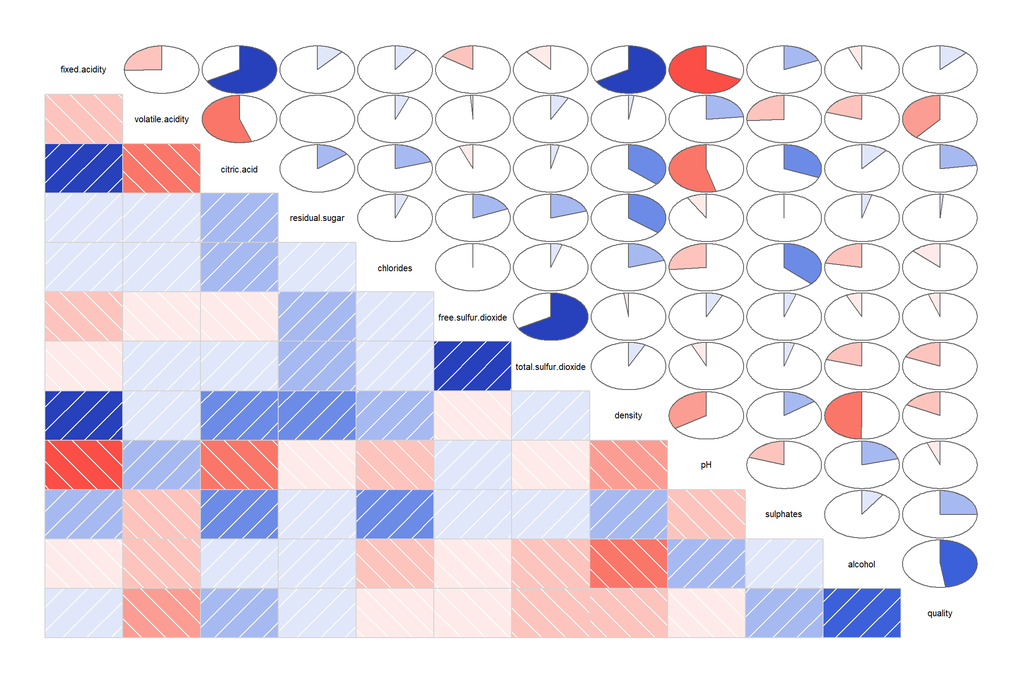

> Observações sobre o correlograma:

Será analisado apartir da qualidade até a acidez fixa, da direita para esqueda da referencia da direita para esquerda.

- Qualidade: está razoavelmente correlacionada positivamente com o alcool (0.476), e sulfato e acido citrico (~0.25), e negativamente acidez volatil (-0.391), pois níveis muito altos levam ao gosto avinagrado
- Alcool: está correlacionado negativamente com a densidade (-0.496), além disso, é a quantidade de álcool que reduz a densidade, devido à química, portanto, a quantidade de álcool é uma boa escolha como um indicador de qualidade do vinho, e volatile.acidity,chlorides, total.sulfur.dioxide de (~-0.2) e positivamente com pH (~-0.2)
- pH: está correlacionado negativamente com acidez fixa (-0.68), acido citrico(-0.54), cloreto e densidade (-0.34) e positivamente com a acidez volátil (0.23).
- Densidade: esta fortemente correlacionada positivamente com a acidez fixa (0.668), e razoavelmente com a acidez citrica e residual de açucar (~0.35) e cloridrato (0.2)
- Dioxido de enxofre total: esta fortemente correlacionada positivamente com dioxido de enxofre livre (0.668) e residual de açucar (0.2)
- Dioxido de enxofre livre: não possui uma correção muito forte positivamente com açucar residual (0.1870) e negativamente com acidez fixa (-0.1538)
- Cloridrato: esta correlacionado positivamente com acido citrico (0.20)
- Açucar residual: possui uma leve correlação positiva
- Ácido citrico: está bem correlacionado negativamente com acidez volatil (-0.552) e positivamente com acidez fixa (0.672)
- Acidez volatil: esta correlacionada negativamente com acidez fixa (-0.256)

> Avaliando não possui nenhuma correlação muito forte, as relações mais fortes estão entre 0,5 e 0,7 positiva e negativa

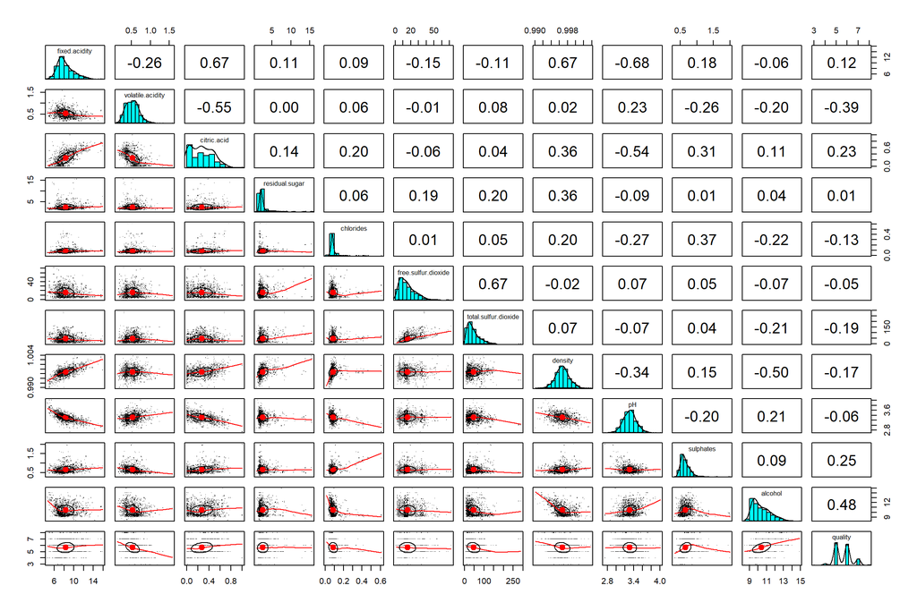

> Verificação de relação da qualidade com demais variáveis, com base em regressão linear,

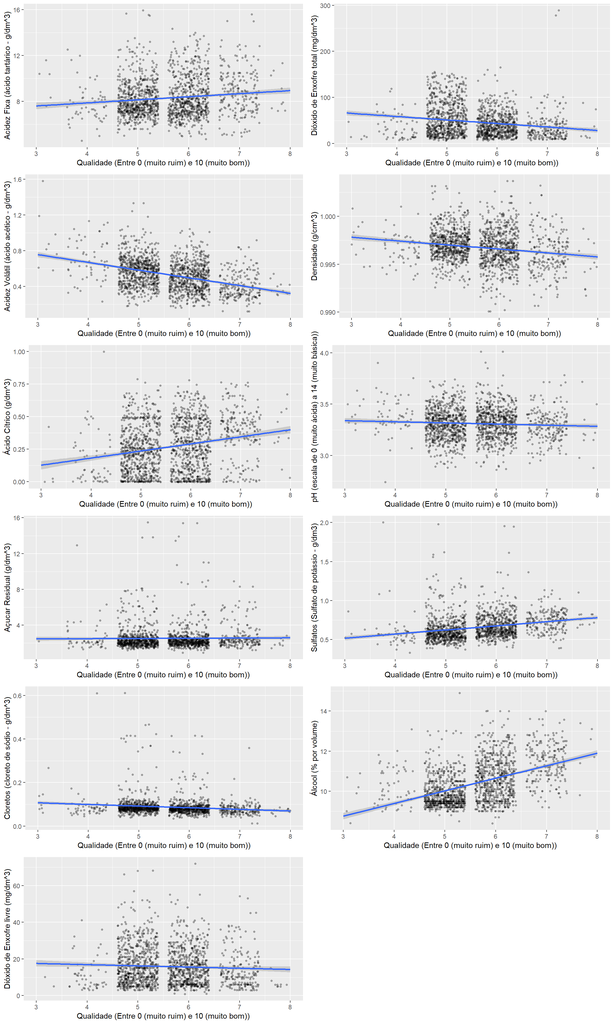

> Com base na verificação os principais atributos para análise são: Acidez Fixa, Acidez Volatil, Ácido Cítrico, Dioxo de Enxofre Total, Densidade, Sulfatos, Alcool

> Como o Açucar Residual, Cloretos, Dioxido de Enxofre, pH estão com baixa correlação dentre a qualidade dos vinhos, e como a qualidade é o intuito da análise, não irei utiliza-los na análises por não serem variáveis de alta relevância neste momento

> Para simplificar a análise irei utilizar a variável variavel criada “total.acidity”

> Portanto será utilizado as variáveis:
- total.sulfur.dioxide
- density
- sulphates
- alcohol
- quality
- total.acidity

```
##                      total.sulfur.dioxide     density  sulphates
## total.sulfur.dioxide           1.00000000  0.07126948 0.04294684
## density                        0.07126948  1.00000000 0.14850641
## sulphates                      0.04294684  0.14850641 1.00000000
## alcohol                       -0.20565394 -0.49617977 0.09359475
## quality                       -0.18510029 -0.17491923 0.25139708
## total.acidity                 -0.09627567  0.67559618 0.18160349
##                          alcohol    quality total.acidity
## total.sulfur.dioxide -0.20565394 -0.1851003   -0.09627567
## density              -0.49617977 -0.1749192    0.67559618
## sulphates             0.09359475  0.2513971    0.18160349
## alcohol               1.00000000  0.4761663   -0.06666786
## quality               0.47616632  1.0000000    0.10375373
## total.acidity        -0.06666786  0.1037537    1.00000000
```

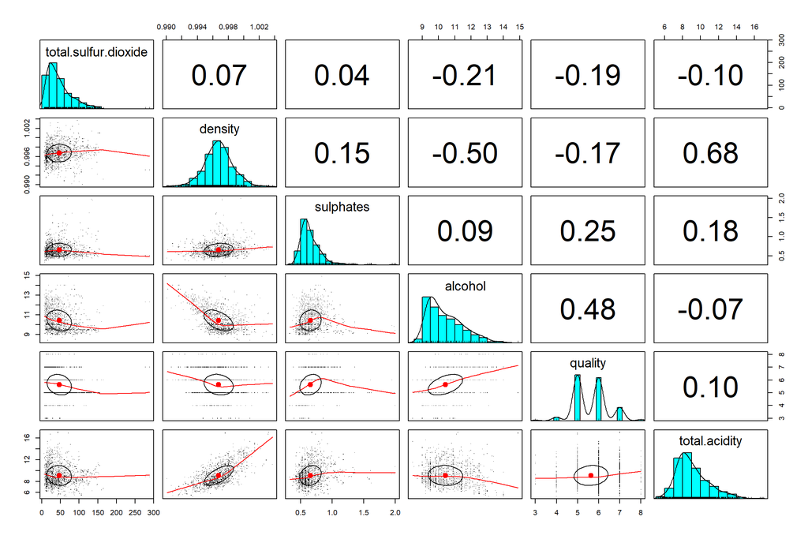

> O objetivo principal é saber como esses recursos afetam a qualidade do vinho, mas primeiro, para não ver como os outros recursos estão relacionados.

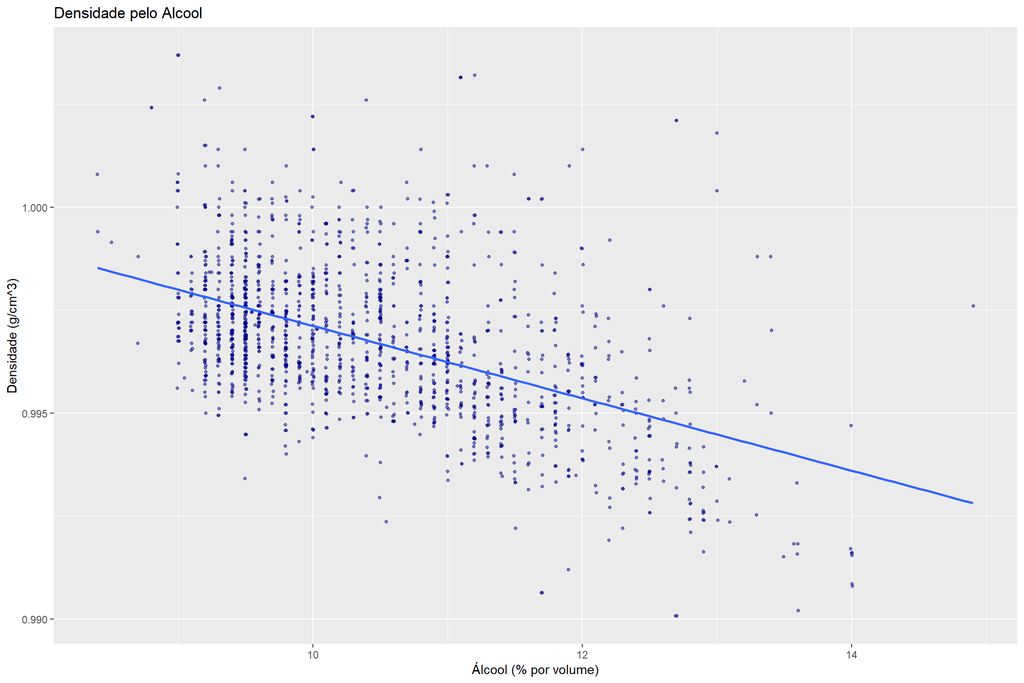

> Aqui está uma relação mediana entre o álcool e a densidade do vinho. De fato, a correlação é de -0,5.

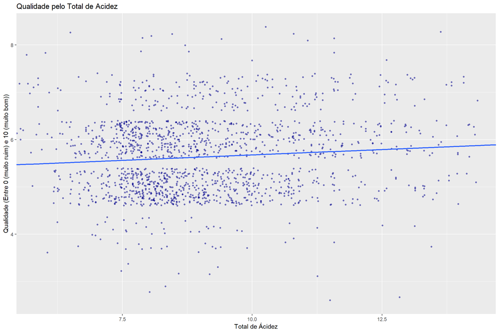

> O valor de correlação para esses pares é 0,1, nenhuma relação pode ser mostrada, vendo o modelo linear dessas características (linha azul) podemos ver quase uma linha horizontal. Isso significa que a inclinação (valor de acidez total) tem muito pouca importância nessa equação.

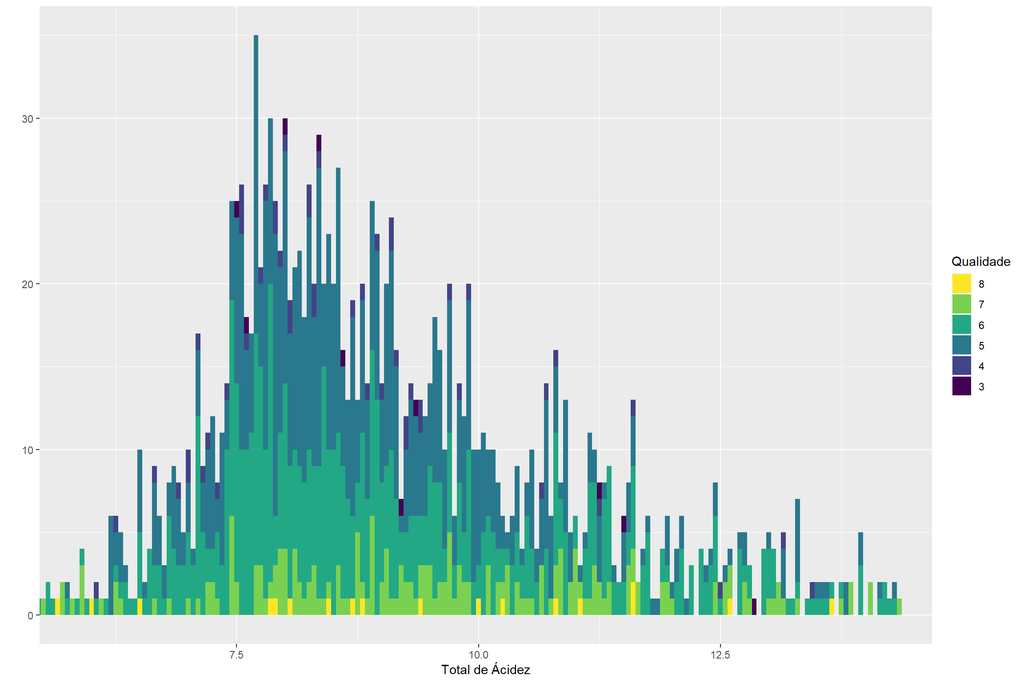

```
## quality: 3
##    Min. 1st Qu.  Median    Mean 3rd Qu.    Max.
##   7.480   8.101   8.883   9.415  10.780  12.840
## --------------------------------------------------------
## quality: 4
##    Min. 1st Qu.  Median    Mean 3rd Qu.    Max.
##   5.270   7.570   8.300   8.647   9.300  13.450
## --------------------------------------------------------
## quality: 5
##    Min. 1st Qu.  Median    Mean 3rd Qu.    Max.
##   5.770   7.880   8.600   8.988   9.830  16.910
## --------------------------------------------------------
## quality: 6
##    Min. 1st Qu.  Median    Mean 3rd Qu.    Max.
##   5.390   7.710   8.640   9.118  10.186  15.350
## --------------------------------------------------------
## quality: 7
##    Min. 1st Qu.  Median    Mean 3rd Qu.    Max.
##   5.320   8.105   9.470   9.651  10.980  17.045
## --------------------------------------------------------
## quality: 8
##    Min. 1st Qu.  Median    Mean 3rd Qu.    Max.
##   5.660   7.933   9.095   9.381  11.002  13.630
```

```
## quality: 3
## [1] 10
## --------------------------------------------------------
## quality: 4
## [1] 53
## --------------------------------------------------------
## quality: 5
## [1] 681
## --------------------------------------------------------
## quality: 6
## [1] 638
## --------------------------------------------------------
## quality: 7
## [1] 199
## --------------------------------------------------------
## quality: 8
## [1] 18
```

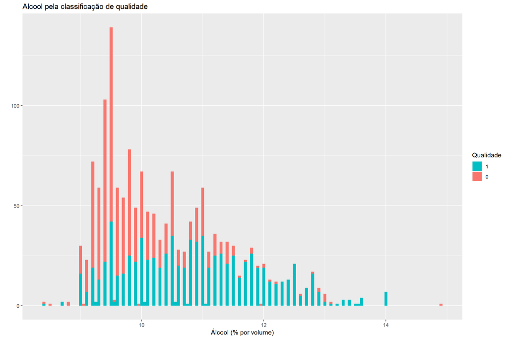

```
## quality.classification: 0
##    Min. 1st Qu.  Median    Mean 3rd Qu.    Max.
##   8.400   9.400   9.700   9.926  10.300  14.900
## --------------------------------------------------------
## quality.classification: 1
##    Min. 1st Qu.  Median    Mean 3rd Qu.    Max.
##    8.40   10.00   10.80   10.86   11.70   14.00
```

```
## quality.classification: 0
## [1] 744
## --------------------------------------------------------
## quality.classification: 1
## [1] 855
```

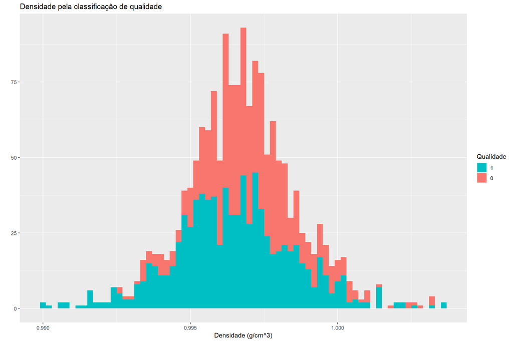

```
## quality.classification: 0
##    Min. 1st Qu.  Median    Mean 3rd Qu.    Max.
##  0.9926  0.9961  0.9969  0.9971  0.9979  1.0031
## --------------------------------------------------------
## quality.classification: 1
##    Min. 1st Qu.  Median    Mean 3rd Qu.    Max.
##  0.9901  0.9952  0.9964  0.9965  0.9977  1.0037
```

```
## quality.classification: 0
## [1] 744
## --------------------------------------------------------
## quality.classification: 1
## [1] 855
```

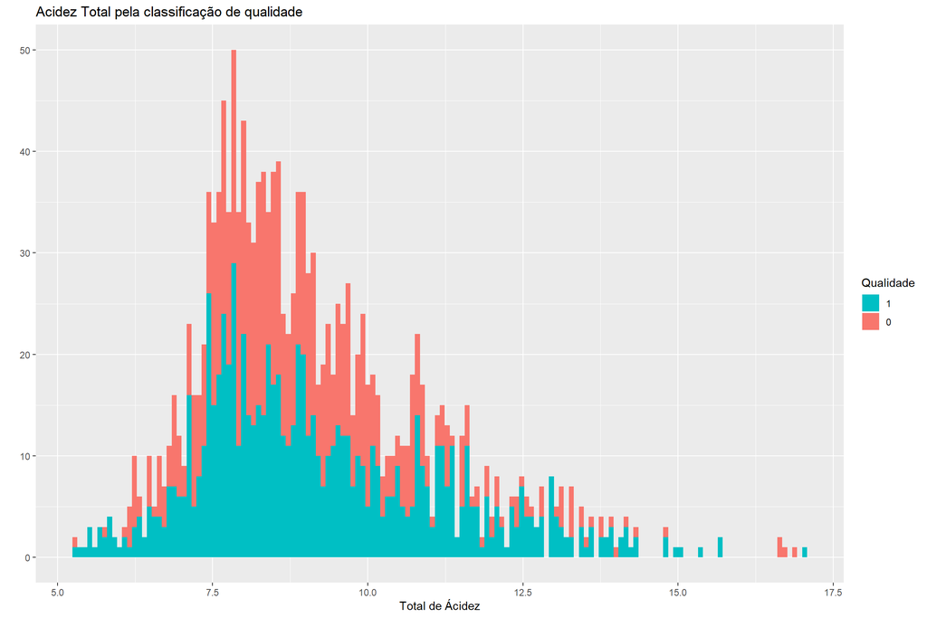

```
## quality.classification: 0
##    Min. 1st Qu.  Median    Mean 3rd Qu.    Max.
##   5.270   7.860   8.592   8.969   9.801  16.910
## --------------------------------------------------------
## quality.classification: 1
##    Min. 1st Qu.  Median    Mean 3rd Qu.    Max.
##   5.320   7.795   8.850   9.248  10.495  17.045
```

```
## quality.classification: 0
## [1] 744
## --------------------------------------------------------
## quality.classification: 1
## [1] 855
```

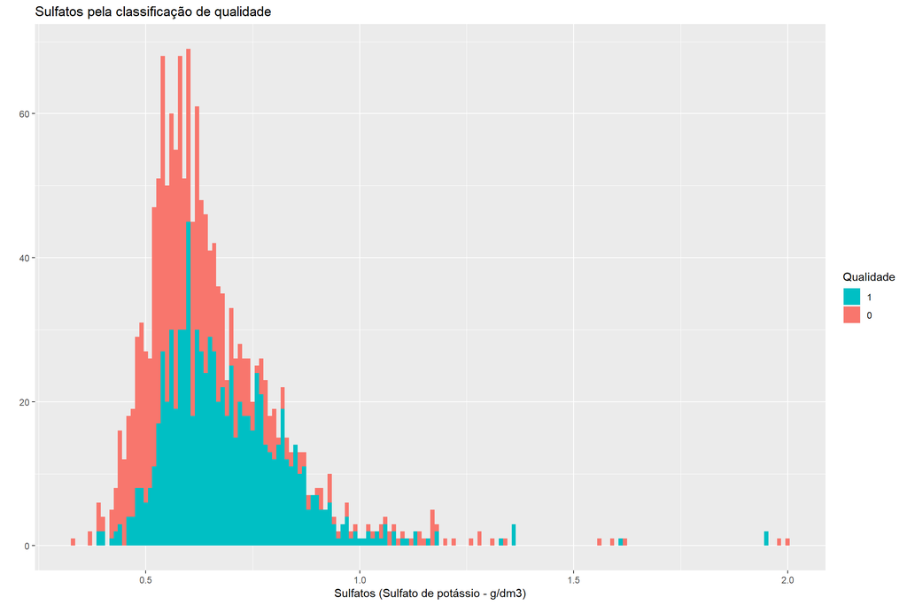

```
## quality.classification: 0
##    Min. 1st Qu.  Median    Mean 3rd Qu.    Max.
##  0.3300  0.5200  0.5800  0.6185  0.6500  2.0000
## --------------------------------------------------------
## quality.classification: 1
##    Min. 1st Qu.  Median    Mean 3rd Qu.    Max.
##  0.3900  0.5900  0.6600  0.6926  0.7700  1.9500
```

```
## quality.classification: 0
## [1] 744
## --------------------------------------------------------
## quality.classification: 1
## [1] 855
```

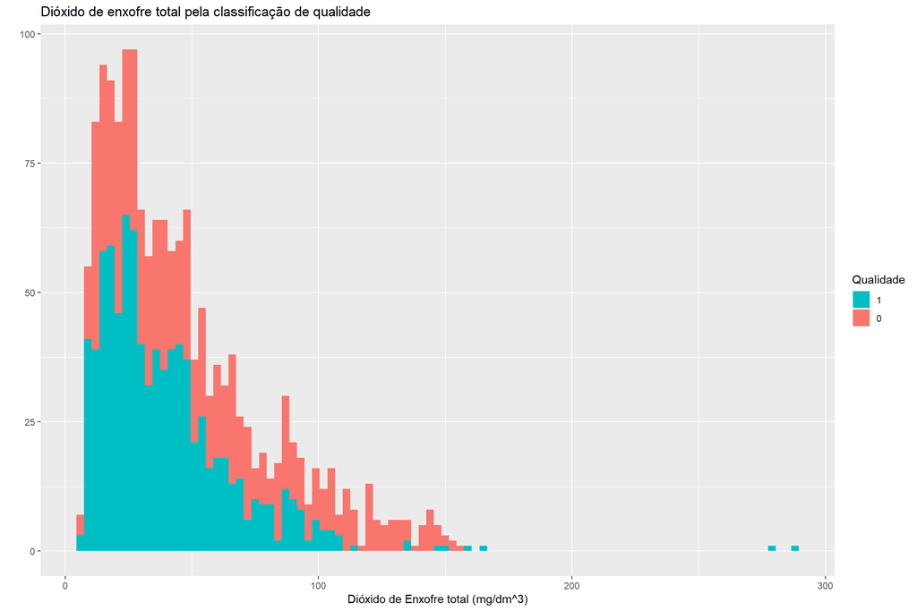

```
## quality.classification: 0
##    Min. 1st Qu.  Median    Mean 3rd Qu.    Max.
##    6.00   23.75   45.00   54.65   78.00  155.00
## --------------------------------------------------------
## quality.classification: 1
##    Min. 1st Qu.  Median    Mean 3rd Qu.    Max.
##    6.00   20.00   33.00   39.35   50.00  289.00
```

```
## quality.classification: 0
## [1] 744
## --------------------------------------------------------
## quality.classification: 1
## [1] 855
```

# Análise Bivariada

### Discuta sobre alguns dos relacionamentos observados nesta parte da investigação. Como os atributos de interesse variaram no conjunto de dados?

> Conforme análisado, nenhuma das variáveis por si só possuem uma correlação muito forte com a qualidade, porém as variáveis que possuem maior correlação com a qualidade são o alcool positivamente com 0.476 e a acidez volatil negativamente -0.391, e uma correlação leve positiva com sulfatos e ácido citrico de aproximadamente de 0.25

> O acido cítrico possui uma ligeria correlação moderada com a acidez fixa, acidez volátil, pH, assim como com a qualidade.

> O açucar residual possui uma correlação muito baixa com os outros elementos, apenas possui uma pequena correlaçãom com a densidade de 0.35

> O Dióxido de enxofre livre e total posuem uma correlação média para alta entre eles.

> Dioxido de enxofre total: quanto menor, melhor a qualidade, a mediana é menor que 33 que a de vinhos com pior qualidade 45

> A densidade possui uma correlação media entre a acidez fixa e o alcool, quanto maior a densidade, tende ter mais vinhos com qualidade pior.

> O Sulfato não possui correlação forte com nenhum elemento, quanto maior a mediana e a media maior a qualidade, sendo assim

> alcool possui uma relação mediana tendendo a fraca proximo de +/- 0.5 com a qualidade e a densidade, sendo assim favorece o entendimento que o autor nos passou que a densidade e o alcool possuem uma relação quantitativa, pois dependendo do percentual do alcool possui maior ou menor densidade, a correlação com açucar residual não possui um relacionamnto tão forte com a densidade e nem com o alcool, quanto maior o nível de alcool maior a quantidade de registro com qualidade de vinhos de boa qualidade

### Você observou algum relacionamento interessante entre os outros atributos (os que não são de interesse)?

> Os relacionamentos mais interessantes que encontrei envolvem o recurso de acido citrico pois possui correlação com acidez volatil, acidez fixa, densidade e pH, assim como acidez fixa que possui acidez fixa, acido citrico, densidade, pH

### Qual foi o relacionamento mais forte encontrado?

> O Relacionamneto mais forte encontrado foi entre o pH e a acidez fixa de : -0.683, e a correlação mais forte com a variável de qualidade foi com o alcool de : 0.476

# Seção de Gráficos Multivariados

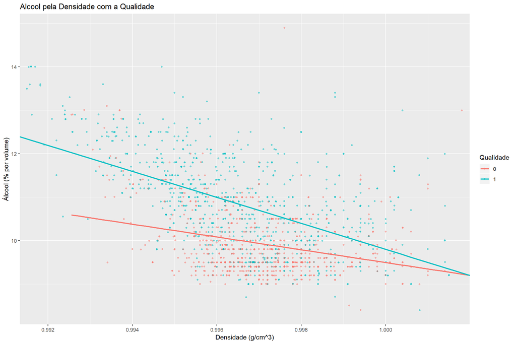

> Aqui podemos ver que com valores com maior qualidade, os valores de densidade pelo álcool parecem estar no canto esquerdo do gráfico e com os valores mais baixos, observando o gráfico se entende que a concentração de baixa qualidade esta com a quantidade menor de alcool, assim como a densidade esta dispersa

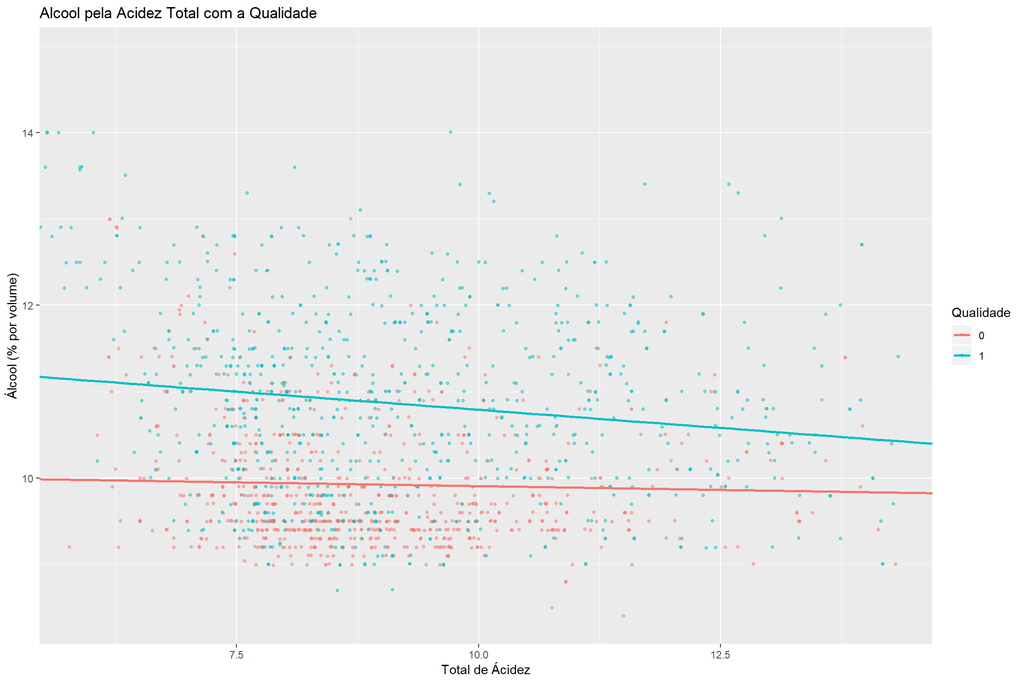

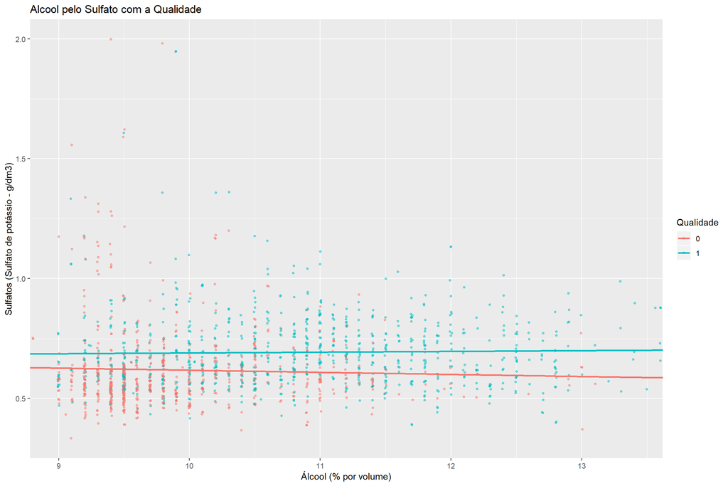

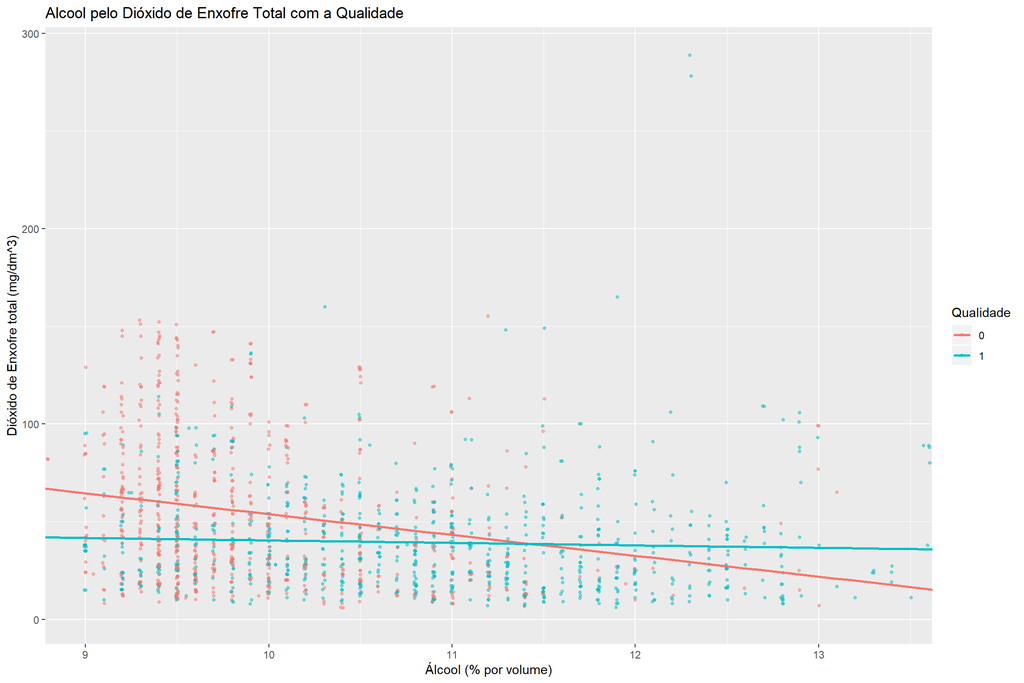

[figure not shown]

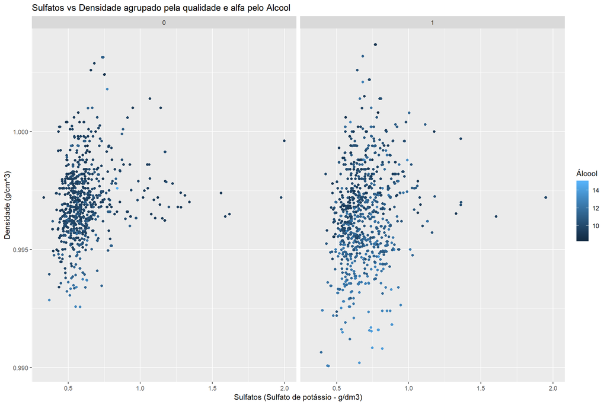

> Regressão Linear

```
##
## Call:
## lm(formula = quality ~ alcohol + density + fixed.acidity + volatile.acidity +
##     citric.acid + sulphates + total.sulfur.dioxide, data = red_wine_quality)
##
## Residuals:
##      Min       1Q   Median       3Q      Max
## -2.78316 -0.36672 -0.06091  0.44289  2.05714
##
## Coefficients:
##                        Estimate Std. Error t value Pr(>|t|)
## (Intercept)           2.730e+01  1.515e+01   1.802 0.071729 .
## alcohol               2.878e-01  2.004e-02  14.362  < 2e-16 ***
## density              -2.492e+01  1.519e+01  -1.641 0.101070
## fixed.acidity         6.325e-02  1.722e-02   3.673 0.000248 ***
## volatile.acidity     -1.258e+00  1.160e-01 -10.852  < 2e-16 ***
## citric.acid          -3.583e-01  1.398e-01  -2.563 0.010471 *
## sulphates             7.468e-01  1.036e-01   7.206 8.86e-13 ***
## total.sulfur.dioxide -1.712e-03  5.286e-04  -3.239 0.001224 **
## ---
## Signif. codes:  0 '***' 0.001 '**' 0.01 '*' 0.05 '.' 0.1 ' ' 1
##
## Residual standard error: 0.6527 on 1591 degrees of freedom
## Multiple R-squared:  0.3496, Adjusted R-squared:  0.3468
## F-statistic: 122.2 on 7 and 1591 DF,  p-value: < 2.2e-16
```

> O R^2 ajustado é 34,6% com um p-value 2.2e-16 portanto aceitável, o valor é muito baixo

> Arvore de Decisão

```
## Call:
## rpart(formula = quality.classification ~ alcohol + density +
##     fixed.acidity + volatile.acidity + citric.acid + sulphates +
##     total.sulfur.dioxide, data = red_wine_quality, method = "class")
##   n= 1599
##
##           CP nsplit rel error    xerror       xstd
## 1 0.36021505      0 1.0000000 1.0000000 0.02680849
## 2 0.02486559      1 0.6397849 0.6747312 0.02494354
## 3 0.01814516      3 0.5900538 0.6142473 0.02428253
## 4 0.01344086      5 0.5537634 0.6155914 0.02429844
## 5 0.01209677      8 0.5094086 0.6142473 0.02428253
## 6 0.01075269      9 0.4973118 0.6021505 0.02413679
## 7 0.01000000     10 0.4865591 0.6061828 0.02418589
##
## Variable importance
##              alcohol            sulphates              density
##                   35                   16                   15
## total.sulfur.dioxide     volatile.acidity          citric.acid
##                   12                   10                    8
##        fixed.acidity
##                    3
##
## Node number 1: 1599 observations,    complexity param=0.3602151
##   predicted class=1  expected loss=0.4652908  P(node) =1
##     class counts:   744   855
##    probabilities: 0.465 0.535
##   left son=2 (842 obs) right son=3 (757 obs)
##   Primary splits:
##       alcohol              < 10.25    to the left,  improve=133.67330, (0 missing)
##       sulphates            < 0.585    to the left,  improve= 77.22690, (0 missing)
##       volatile.acidity     < 0.5475   to the right, improve= 67.93661, (0 missing)
##       total.sulfur.dioxide < 81.5     to the right, improve= 45.56073, (0 missing)
##       density              < 0.995685 to the right, improve= 44.52363, (0 missing)
##   Surrogate splits:
##       density              < 0.995745 to the right, agree=0.707, adj=0.382, (0 split)
##       volatile.acidity     < 0.515    to the right, agree=0.620, adj=0.197, (0 split)
##       citric.acid          < 0.315    to the left,  agree=0.611, adj=0.178, (0 split)
##       sulphates            < 0.675    to the left,  agree=0.610, adj=0.176, (0 split)
##       total.sulfur.dioxide < 47.5     to the right, agree=0.600, adj=0.156, (0 split)
```

[output cut: 185 more lines]

```
##       volatile.acidity     < 0.265    to the right, improve=2.954307, (0 missing)
##       sulphates            < 0.675    to the left,  improve=2.299328, (0 missing)
##   Surrogate splits:
##       sulphates            < 0.985    to the right, agree=0.922, adj=0.167, (0 split)
##       total.sulfur.dioxide < 10.5     to the left,  agree=0.914, adj=0.083, (0 split)
##
## Node number 90: 12 observations
##   predicted class=0  expected loss=0.1666667  P(node) =0.00750469
##     class counts:    10     2
##    probabilities: 0.833 0.167
##
## Node number 91: 116 observations
##   predicted class=1  expected loss=0.3448276  P(node) =0.07254534
##     class counts:    40    76
##    probabilities: 0.345 0.655
```

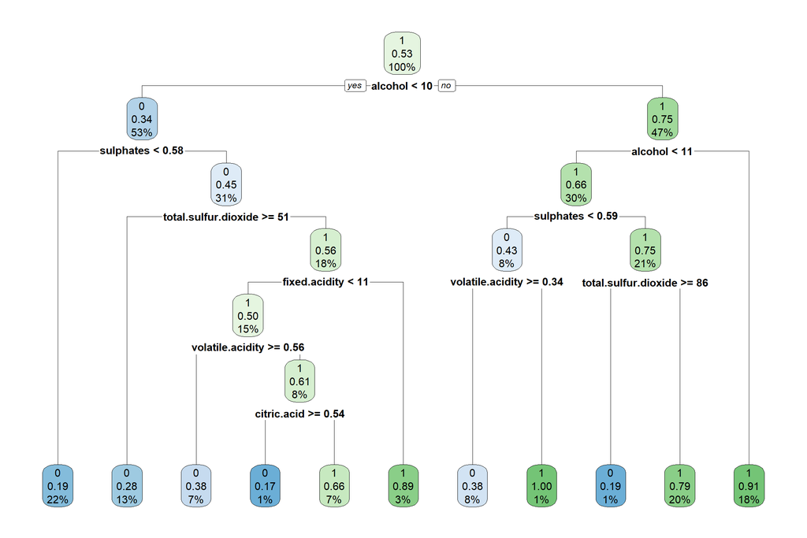

```
## [1] "Erro do modelo"
```

```
## [1] 0.2263915
```

```
## [1] "Acerto do modelo"
```

```
## [1] 0.7736085
```

# Análise Multivariada

### Discuta sobre os relacionamentos observados nesta parte da investigação. Quais atributos que fortaleceram os demais na observação das variáveis de interesse?

> Como avaliado e fui destacando na analise bivariada, portanto fui melhorando minha analise e enriquecendo com a analise multivariada, a analise do alcool comparando com outras variáveis para avaliar a qualidade do vinho, percebi que quanto maior a quantidade de alcool possuia mais observacoes com vinhos de boa qualidade, tambem, quando rodei o modelo de arvore de decisão ele iniciou a arvore com o alcool, pois identificiou como sendo uma variável de alta importancia para o modelo

### Interações surpreendentes e/ou interessantes foram encontradas entre os atributos?

> Como avaliado e fui destacando na analise bivariada, portanto fui melhorando minha analise e enriquecendo com a analise multivariada, a analise do alcool comparando com outras variáveis para avaliar a qualidade do vinho, percebi que quanto maior a quantidade de alcool possuia mais observacoes com vinhos de boa qualidade, tambem, quando rodei o modelo de arvore de decisão ele iniciou a arvore com o alcool, pois identificiou como sendo uma variável de alta importancia para o modelo,

### OPCIONAL: Modelos foram criados usando este conjunto de dados? Discuta sobre os pontos fortes e as limitações do seu modelo.

> Para tentar prever a qualidade do vinho, criei um modelo linear, utilizei as variáveis que defini para alcohol, density, fixed.acidity, volatile.acidity, citric.acid, sulphates, total.sulfur.dioxide para avaliação do modelo, porém para este tipo de dado o modelo de regressão linear não é muito adequado, pois a acurácia é muito baixa com R^2 ajustado é 34,6% com um p-value 2.2e-16

> Fiz outro modelo com arvore de decisão onde tive um acerto de 77,3% na predição, sendo assim o modelo foi muito mais adequado que com a regressão linear, realizei um teste utilizando todas as variáveis do dataset, mesmo assim as variáveis que são utilizadas no modelo são as utilizadas durante a análise exploratória

# Gráficos Finais e descrições

### Primeiro Gráfico

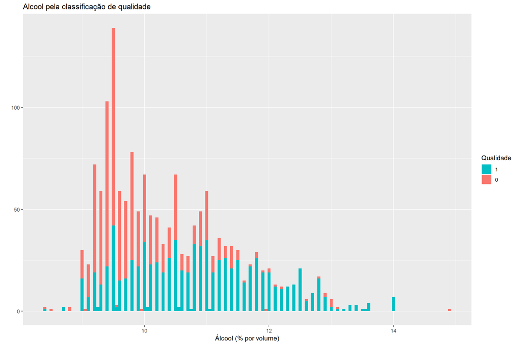

### Descrição do Primeiro Gráfico

> Quando falamos de qualidade em vinho, temos que levar em consideração uma infinidade de sabores, consistência, aroma, cores e longevidade. No entanto, há apreciadores que defendem a ideia de que o teor alcoólico é o grande medidor para afirmar se um vinho é bom ou não. O vinho é composto por mais de 400 substâncias, entre elas o álcool que é o resultado da fermentação entre a glicose e a frutose das uvas. De acordo com o que observamos no gráfico acima quanto mais álcool mais saboroso e com uma qualidade maior será o vinho. Sempre na medida, o álcool é bastante importante para preservar a essência do vinho, tanto enquanto bebida, como um fator sociável de quem o aprecia. Sua presença e influência no sabor macio e adocicado de um vinho sempre será na proporção contrária da presença ácida e tanina que um tipo vinícola pode ter.

### Segundo Gráfico

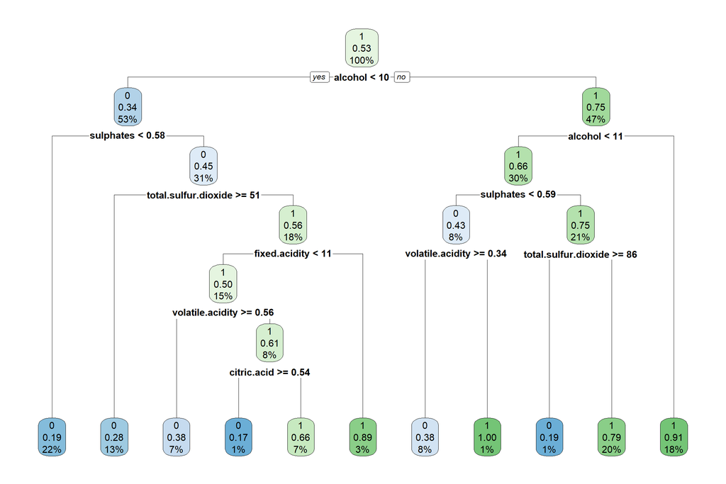

### Terceiro Gráfico

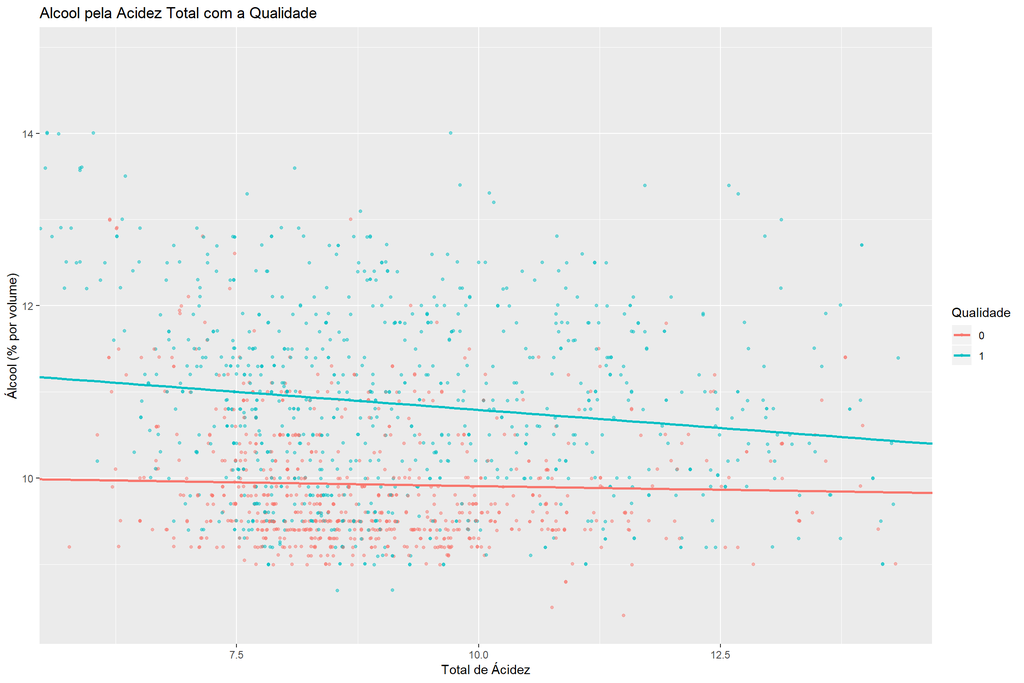

# Reflexão

> O que pudemos aprender com esta análise é que vinhos com graduações alcoólicas semelhantes também terão perfis parecidos. É claro que eles não serão exatamente os mesmos, mas certamente estão inseridos em grupos bastante próximos uns aos outros. A graduação alcoólica de um vinho é um ponto importante a ser considerado ao avaliar sua qualidade. O equilíbrio perfeito entre ela e todas as nuances de sabores e aromas, além de acidez e presença de taninos é o que fazem um bom rótulo. Por isso lembre-se de levar todos esses quesitos em consideração para tomar a decisão mais rica possível.